# Methanoperedenacaea phylogeny

# Workflow

1. Use GToTree to create a rooted tree for Methanoperedenacaeae genomes with an outgroup
2. Visualize phylogenetic trees in R
3. Run the Methanoperedenaceae genomes available from GTDB through the DRAM workflow
4. Reproduce the heatmaps from DRAM in R

# Software and package versions

- Ran the sessionInfo() command on 2022-12-19 following Rstudio and R package updates

R version 4.1.2 (2021-11-01) Platform: x86_64-apple-darwin17.0 (64-bit) Running under: macOS Monterey 12.3.1

Matrix products: default LAPACK: /Library/Frameworks/R.framework/Versions/4.1/Resources/lib/libRlapack.dylib

locale: [1] en_CA.UTF-8/en_CA.UTF-8/en_CA.UTF-8/C/en_CA.UTF-8/en_CA.UTF-8

attached base packages: [1] stats graphics grDevices utils datasets methods base

other attached packages: [1] ggtree_3.0.4 tidytree_0.4.1 treeio_1.16.2 ggtext_0.1.2 patchwork_1.1.2 RColorBrewer_1.1-3 data.table_1.14.6 forcats_0.5.2  
[9] stringr_1.5.0 dplyr_1.0.10 purrr_0.3.5 readr_2.1.3 tidyr_1.2.1 tibble_3.1.8 ggplot2_3.4.0 tidyverse_1.3.2

loaded via a namespace (and not attached): [1] nlme_3.1-160 fs_1.5.2 lubridate_1.9.0 httr_1.4.4 tools_4.1.2 backports_1.4.1 bslib_0.4.1  
[8] utf8_1.2.2 R6_2.5.1 DBI_1.1.3 lazyeval_0.2.2 colorspace_2.0-3 withr_2.5.0 tidyselect_1.2.0  
[15] compiler_4.1.2 textshaping_0.3.6 cli_3.4.1 rvest_1.0.3 xml2_1.3.3 labeling_0.4.2 sass_0.4.4  
[22] scales_1.2.1 commonmark_1.8.1 systemfonts_1.0.4 digest_0.6.30 yulab.utils_0.0.5 rmarkdown_2.18 pkgconfig_2.0.3  
[29] htmltools_0.5.4 dbplyr_2.2.1 fastmap_1.1.0 rlang_1.0.6 readxl_1.4.1 rstudioapi_0.14 gridGraphics_0.5-1 [36] jquerylib_0.1.4 farver_2.1.1 generics_0.1.3 jsonlite_1.8.4 googlesheets4_1.0.1 magrittr_2.0.3 ggplotify_0.1.0  
[43] Rcpp_1.0.9 munsell_0.5.0 fansi_1.0.3 ape_5.6-2 lifecycle_1.0.3 stringi_1.7.8 yaml_2.3.6  
[50] grid_4.1.2 parallel_4.1.2 crayon_1.5.2 lattice_0.20-45 haven_2.5.1 gridtext_0.1.5 hms_1.1.2  
[57] knitr_1.41 pillar_1.8.1 markdown_1.4 reprex_2.0.2 glue_1.6.2 evaluate_0.18 ggfun_0.0.9  
[64] modelr_0.1.10 vctrs_0.5.1 tzdb_0.3.0 cellranger_1.1.0 gtable_0.3.1 assertthat_0.2.1 cachem_1.0.6  
[71] xfun_0.35 broom_1.0.1 ragg_1.2.4 googledrive_2.0.0 gargle_1.2.1 aplot_0.1.9 timechange_0.1.1  
[78] ellipsis_0.3.2

Additional packages employed in terminal: - GToTree v1.5.38 - bit v1.8.53 - DRAM v1.2

# 1. Use GToTree to create a rooted tree for Methanoperedenacaeae genomes with an outgroup

1. Activate GtoTree and create a dedicated directory to house all the files you’ll need for the tree. Copy any assemblies over you’d like to this directory and put them in a list in a .txt format to call when running GToTree.

```bash
source activate gtotree
mkdir ~/name/directory

cp ~/Example_MAG.fasta ~/name/directory

ls *fasta > Methanoperedenaceae_revised_curated_assembly_fasta_files.txt
```

2. Retrieve all the GTDB accession numbers for your family of interest and include others within the order to create an outgroup.

```bash
gtt-get-accessions-from-GTDB -t Methanosarcinaceae --GTDB-representatives-only
gtt-get-accessions-from-GTDB -t ANME-2c --GTDB-representatives-only
gtt-get-accessions-from-GTDB -t Methanoperedenaceae --GTDB-representatives-only
```

At the time of running this analysis, the following number of genomes were available in GTDB r202: - Methanosarcinaceae = 66 genomes - ANME-2c = 8 genomes - Methanoperedenaceae = 14 genomes

3. Append all of these files to each other and rename the file.

```bash
cat GTDB-ANME-2c-family-GTDB-rep-accs.txt >> GTDB-Methanosarcinaceae-family-GTDB-rep-accs.txt
cat GTDB-Methanoperedenaceae-family-GTDB-rep-accs.txt >> GTDB-Methanosarcinaceae-family-GTDB-rep-accs.txt
mv GTDB-Methanosarcinaceae-family-GTDB-rep-accs.txt GTDB-Methanosarcinaceae-ANME-2c-Methanoperedenaceae-family-GTDB-rep-accs.txt
```

4. Run the GToTree script on all of the input genome. In this case, we will call the MAGs of interest using the -f flag which calls from a list of .fasta file, whereas we will input the genomes retrievd from GTDB using the -a flag, which works from a collated listed of accession numbers.

```bash
ls *fasta > Methanoperedenaceae_revised_curated_assembly_fasta_files.txt

GToTree -f Methanoperedenaceae_revised_curated_assembly_fasta_files.txt\
        -a GTDB-Methanosarcinaceae-ANME-2c-Methanoperedenaceae-family-GTDB-rep-accs.txt \
        -L Family,Genus,Species \
        -H Archaea -D -j 4 \
        -o Methanoperedenaceae_rooted_tree_revised_curated_assemblies
```

**Note**: From here, you can export the files to your personal machine to work with them in R to create visualizations.

# 2. Visualize phylogenetic trees in R

1. Install ‘ggtree’ using the bioconductor pacakage if you have not already.

```r
if (!requireNamespace("BiocManager", quietly = TRUE))
    install.packages("BiocManager")

BiocManager::install("ggtree")
```

2. Read the .tre file containing a phylogentic tree in a newick format using the ‘treeio’ package that will be installed using the command from step 1.

```r
library(treeio)
Methanoperedenaceae_tree<-read.newick("Methanoperedenaceae_rooted_tree_revised_curated_assemblies.tre")
```

3. Convert the tree to a data object that can be examined in R. Manually edit the ‘label’ variable to provide more informative labels for the genomes of interest. You do not need to do this for all of the genomes included because the tree nodes will be collapsed in subsequent steps.

```r
library(tidytree)
library(tidyverse)
Methanoperedenaceae_tree_file_data<- Methanoperedenaceae_tree %>% as.treedata %>% as_tibble

Methanoperedenaceae_tree_relabel<- Methanoperedenaceae_tree_file_data %>%
mutate(label = recode( #manually recode the labels here making sure to preserve original label output by GToTree
       label,
"GCA_013331375.1_Methanoperedenaceae_UBA10536_UBA10536_sp10536u" =  "UBA10536 sp10536u (GCA_013331375.1)",
"GCA_002839545.1_Methanoperedenaceae_Methanoperedens_A_Methanoperedens_A_sp002839545" = "Methanoperedens A sp002839545 (GCA_002839545.1)",
"GCA_902386255.1_Methanoperedenaceae_Methanoperedens_Methanoperedens_sp902386255" = "Methanoperedens sp902386255 (GCA_902386255.1)",
"GCA_003104905.1_Methanoperedenaceae_Methanoperedens_Methanoperedens_sp003104905" = "Methanoperedens sp003104905 (GCA_003104905.1)",
"GCA_012026795.1_Methanoperedenaceae_Methanoperedens_Methanoperedens_sp012026795" = "Methanoperedens sp012026795 (GCA_012026795.1)",
"GCF_002487355.1_Methanoperedenaceae_Methanoperedens_Methanoperedens_sp002487355" = "Methanoperedens sp002487355 (GCF_002487355.1)",
"GCA_902384525.1_Methanoperedenaceae_Methanoperedens_Methanoperedens_sp902384525" = "Methanoperedens sp902384525 (GCA_902384525.1)",
"GCA_012026835.1_Methanoperedenaceae_Methanoperedens_Methanoperedens_sp012026835" = "Methanoperedens sp012026835 (GCA_012026835.1)",
"GCA_902386205.1_Methanoperedenaceae_Methanoperedens_Methanoperedens_sp902386205" = "Methanoperedens sp902386205 (GCA_902386205.1)",
"GCA_902386115.1_Methanoperedenaceae_Methanoperedens_Methanoperedens_sp902386115" = "Methanoperedens sp902386115 (GCA_902386115.1)",
"GCF_900196725.1_Methanoperedenaceae_Methanoperedens_Methanoperedens_nitroreducens_A" = "Methanoperedens nitroreducens A (GCF_900196725.1)",
"GCA_902386135.1_Methanoperedenaceae_Methanoperedens_Methanoperedens_sp902386135" = "Methanoperedens sp902386135 (GCA_902386135.1)",
"GCF_000685155.1_Methanoperedenaceae_Methanoperedens_Methanoperedens_nitroreducens" = "Methanoperedens nitroreducens (GCF_000685155.1)",
"GCA_902386085.1_Methanoperedenaceae_Methanoperedens_Methanoperedens_sp902386085" = "Methanoperedens sp902386085 (GCA_902386085.1)",
"STD1_6_scaffolds_2500" = "Methanoperedens sp. (MAG STD1_6)",
"STD1_19_scaffolds_2500" = "Methanoperedens sp. (MAG STD1_19)"
))


Methanoperedenaceae_tree<-as.phylo(Methanoperedenaceae_tree_relabel) #added this here for consistency in case something is getting mixed up
```

4. Create the basic trees to see which nodes need to be collapsed prior to starting the manual relabeling. This is also where we identify the node number to root from.

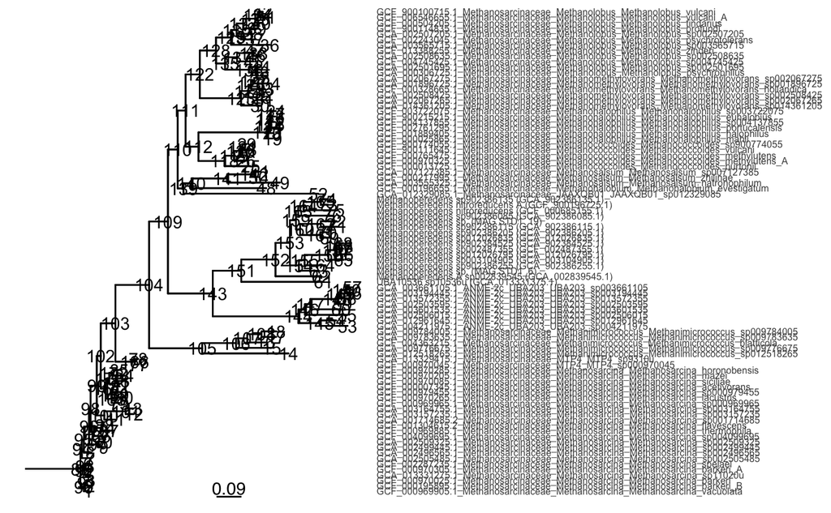

```r
library(ggtree)
#default tree
Methanoperedenaceae_tree_figure<- ggtree(Methanoperedenaceae_tree) +
                                  geom_tree() +
                                  theme_tree() +
                                  geom_treescale() +
                                  geom_tiplab(size=6, as_ylab = TRUE) + #this sets them all along the same axis
                                  geom_rootedge(rootedge = 0.2) +
                                  geom_text(aes(label=node))
Methanoperedenaceae_tree_figure
```

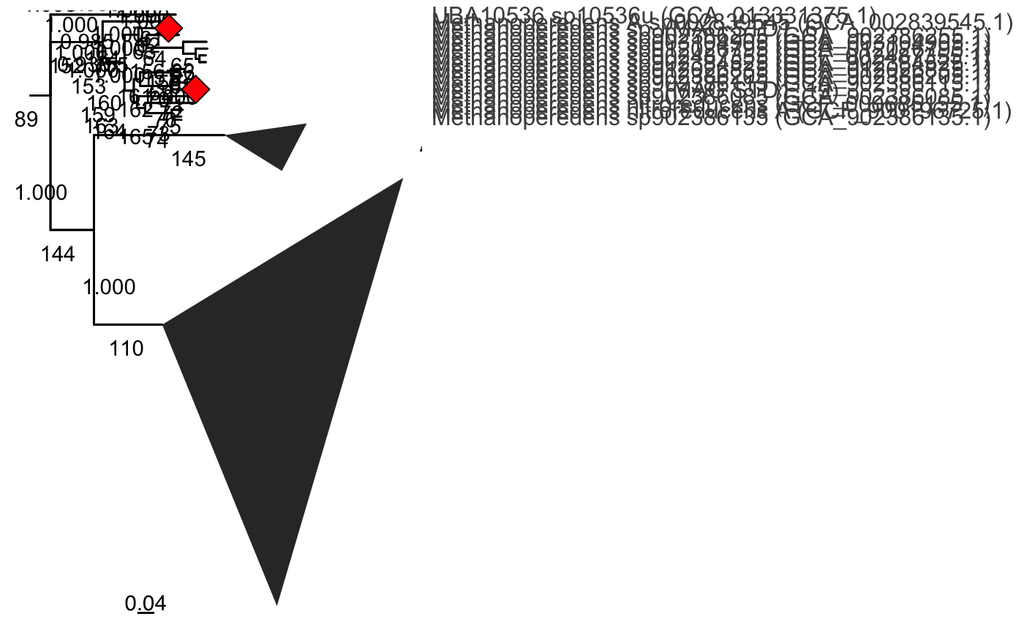

```r
#rooted tree at node 151
Methanoperedenaceae_tree_rooted<-root(Methanoperedenaceae_tree, node =151, edgelabel = TRUE)


Methanoperedenaceae_tree_figure_rooted<-ggtree(Methanoperedenaceae_tree_rooted) %>%
                                            rotate(89) %>% #the rotation needs to be piped in to the same chunk of code to work properly
                                            collapse(node = 145, 'mixed') %>%
                                            collapse(node = 110, 'mixed') +
                                            geom_tree() +
                                            theme_tree() +
                                            geom_treescale() +
                                            geom_tiplab(size=12, as_ylab = TRUE) + #this sets them all along the same axis
                                            geom_nodelab(vjust = -2, hjust = 1.5) +
                                            geom_rootedge(rootedge = 0.05) +
                                            geom_text(aes(label=node), vjust = 2, hjust = 1.5) +
                                            geom_cladelabel(node=145, label="ANME-2c", align = TRUE, fontsize = 8, hjust = -1) +
                                            geom_cladelabel(node=110, label="Methanosarcinaceae", align = TRUE, fontsize = 8, hjust = -1) +
                                            geom_point2(aes(subset=(node == 63)), shape = 23, size = 5, fill = 'red') +
                                            geom_point2(aes(subset=(node == 72)), shape = 23, size = 5, fill = 'red')
Methanoperedenaceae_tree_figure_rooted
```

5. Use this command to re-scale certain clades to improve the visualization.

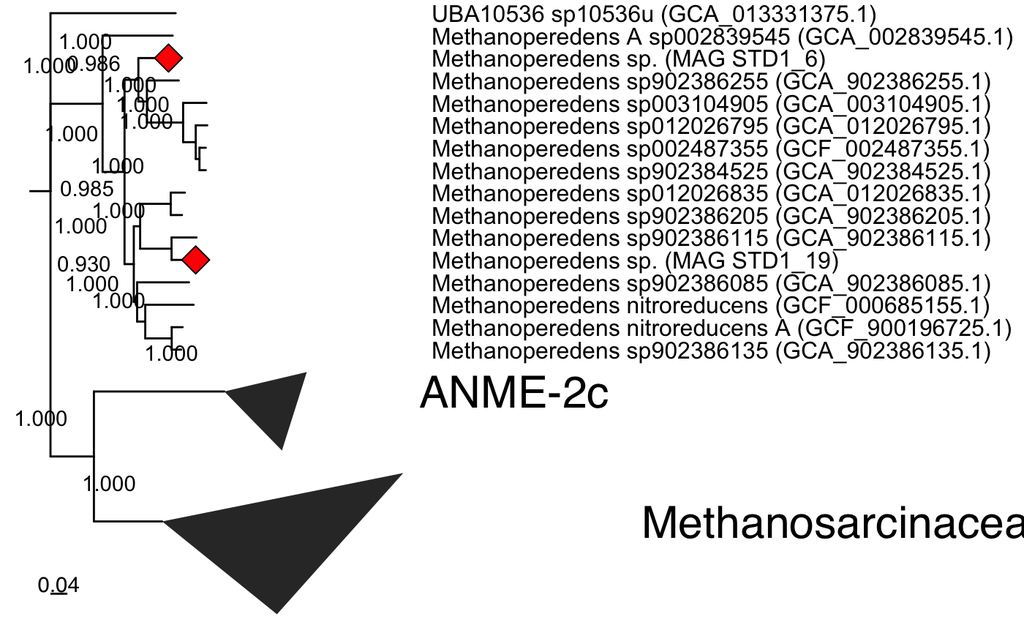

```r
Methanoperedenaceae_tree_figure_rooted_rescaled<- ggtree(Methanoperedenaceae_tree_rooted) %>%
                                                  rotate(89) %>% #the rotation needs to be piped in to the same chunk of code to work properly
                                                  scaleClade(110, scale = 0.1) %>% #this needs to come after rotation argument to work properly
                                                  scaleClade(145, scale = 0.5) %>%
                                                  scaleClade(89, scale = 5) %>%
                                                  collapse(node = 145, 'mixed') %>%
                                                  collapse(node = 110, 'mixed') +
                                                  geom_treescale(x= 0, y=-30) + #reposition scale bar, but not working super well
                                                  theme_tree() +
                                                  geom_tiplab(size=12, as_ylab = TRUE) + #this sets them all along the same axis
                                                  geom_nodelab(vjust = -2, hjust = 1.5) +
                                                  geom_rootedge(rootedge = 0.05) +
                                                  geom_cladelabel(node=145, label="ANME-2c", align = TRUE, fontsize = 8, hjust = -1) +
                                                  geom_cladelabel(node=110, label="Methanosarcinaceae", align = TRUE, fontsize = 8, hjust = -1) +
                                                  geom_point2(aes(subset=(node == 63)), shape = 23, size = 5, fill = 'red') +
                                                  geom_point2(aes(subset=(node == 72)), shape = 23, size = 5, fill = 'red') +
                                                  theme(axis.text.y = element_text(color = "black"))
Methanoperedenaceae_tree_figure_rooted_rescaled<- Methanoperedenaceae_tree_figure_rooted_rescaled + coord_cartesian(clip = "off")

Methanoperedenaceae_tree_figure_rooted_rescaled
```

6. Load in the metadata that was generated as an output from the GToTree workflow.

```r
library(tidyverse)
Methanoperedenaceae_metadata<- read.delim("GTDB-Methanoperedenaceae-family-GTDB-rep-metadata.tsv", sep = "\t", header = TRUE)
```

7. Relabel the metadata so the labels line up properly with the rooted_tree phylo object we’re working with. If these labels don’t line up, we will not be able to display the proper labels on the tree in the end product. Additionally, you can create another data frame that is a list of the NCBI biosample numbers. This list can be used to manually retrieve information on the habitats samples were collected from to append to the tree.

```r
Methanoperedenaceae_metadata_relabel<- Methanoperedenaceae_metadata %>%
                                       rename(label = accession) %>%
                                       mutate(label = recode(
                                             label,
"GB_GCA_013331375.1" =  "UBA10536 sp10536u (GCA_013331375.1)",
"GB_GCA_002839545.1" = "Methanoperedens A sp002839545 (GCA_002839545.1)",
"GB_GCA_902386255.1" = "Methanoperedens sp902386255 (GCA_902386255.1)",
"GB_GCA_003104905.1" = "Methanoperedens sp003104905 (GCA_003104905.1)",
"GB_GCA_012026795.1" = "Methanoperedens sp012026795 (GCA_012026795.1)",
"RS_GCF_002487355.1" = "Methanoperedens sp002487355 (GCF_002487355.1)",
"GB_GCA_902384525.1" = "Methanoperedens sp902384525 (GCA_902384525.1)",
"GB_GCA_012026835.1" = "Methanoperedens sp012026835 (GCA_012026835.1)",
"GB_GCA_902386205.1" = "Methanoperedens sp902386205 (GCA_902386205.1)",
"GB_GCA_902386115.1" = "Methanoperedens sp902386115 (GCA_902386115.1)",
"RS_GCF_900196725.1" = "Methanoperedens nitroreducens A (GCF_900196725.1)",
"GB_GCA_902386135.1" = "Methanoperedens sp902386135 (GCA_902386135.1)",
"RS_GCF_000685155.1" = "Methanoperedens nitroreducens (GCF_000685155.1)",
"GB_GCA_902386085.1" = "Methanoperedens sp902386085 (GCA_902386085.1)"))

Methanoperedenaceae_biosample<-Methanoperedenaceae_metadata_relabel %>% select(ncbi_biosample)
Methanoperedenaceae_biosample
```

| ncbi_biosample |
| --- |
| SAMEA4835441 |
| SAMN10872769 |
| SAMEA4835414 |
| SAMN06767741 |
| SAMEA4835440 |
| SAMN08364719 |
| SAMN10872768 |
| SAMN07620899 |
| SAMEA4835442 |
| SAMEA4835439 |

[output cut: 4 more lines]

8. Recode the metadata again using case_when arguments to manually change the habitats retrieved from NCBI. Below, I provide a list of the habitat information I was able to obtain by manually searching through the Biosample number and associated metadata.

```r
Methanoperedenaceae_metadata_relabel<-
  ggtree(Methanoperedenaceae_tree_rooted, aes(x,y)) %<+%
  Methanoperedenaceae_metadata_relabel %>%
  as.treedata %>%
  as_tibble %>%
  mutate(Habitat = case_when(ncbi_biosample == "SAMEA4835441" ~ "Groundwater from legacy radioactive site",
                            ncbi_biosample == "SAMN10872769" ~ "AOM-Mn Bioreactor",
                            ncbi_biosample == "SAMEA4835414" ~ "Groundwater from legacy radioactive site",
                            ncbi_biosample == "SAMN06767741" ~ "Groundwater from subsurface sediment",
                            ncbi_biosample == "SAMEA4835440" ~ "Groundwater from legacy radioactive site",
                            ncbi_biosample == "SAMN08364719" ~ "AOM-Fe bioreactor",
                            ncbi_biosample == "SAMN10872768" ~ "AOM-Mn Bioreactor",
                            ncbi_biosample == "SAMN07620899" ~ "Sediment enrichment - NO3",
                            ncbi_biosample == "SAMEA4835442" ~ "Groundwater from legacy radioactive site",
                            ncbi_biosample == "SAMEA4835439" ~ "Groundwater from legacy radioactive site",
                            ncbi_biosample == "SAMEA104141092" ~ "Groundwater from legacy radioactive site",
                            ncbi_biosample == "SAMEA4835439" ~ "Paddy soil enrichment",
                            ncbi_biosample == "SAMEA4835438" ~ "Groundwater from legacy radioactive site",
                            ncbi_biosample == "SAMN02713514" ~ "Freshwater sediment enrichment - NO3, NH4+, CH4",
                            ncbi_biosample == "SAMN13192964" ~ "As-contaminated groundwater",
                            label == "Methanoperedens sp. (MAG STD1_6)" ~ "Landfill leachate",
                            label == "Methanoperedens sp. (MAG STD1_19)" ~ "Landfill leachate")) %>%
                                        mutate(Shape_format = case_when(Habitat == "Landfill leachate" ~ "Triangle",
                                                                        !Habitat == "Landfill leachate" ~ "Circle"))
```

9. Recreate the phylogenetic tree with the metadata on habitat appended.

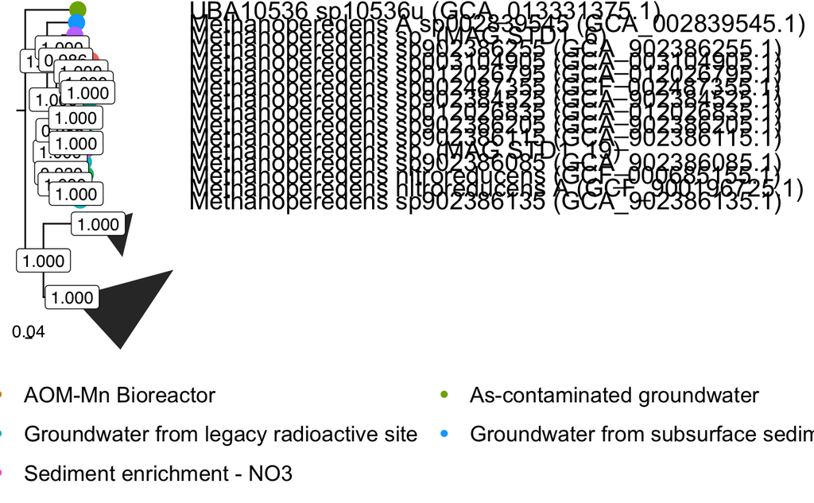

```r
Methanoperedenaceae_tree_figure_rooted_rescaled<- ggtree(Methanoperedenaceae_tree_rooted, aes(x,y)) %<+%
                                                  Methanoperedenaceae_metadata_relabel %>%
                                                  rotate(89) %>% #the rotation needs to be piped in to the same chunk of code to work properly
                                                  scaleClade(110, scale = 0.1) %>% #this needs to come after rotation argument to work properly
                                                  scaleClade(145, scale = 0.5) %>%
                                                  scaleClade(89, scale = 5) %>%
                                                  collapse(node = 145, 'mixed') %>%
                                                  collapse(node = 110, 'mixed') +
                                                  geom_tippoint(aes(color = Habitat, size = 10)) +
                                                  scale_size(guide = "none") +
                                                  scale_color_discrete(na.translate = FALSE) +
                                                  geom_label2(aes(label = label, subset = !is.na(as.numeric(label)) & as.numeric(label))) +
                                                  geom_treescale(x= 0, y=-30) + #reposition scale bar, but not working super well
                                                  theme_tree() +
                                                  geom_tiplab(size=16, as_ylab = TRUE) + #this sets them all along the same axis
                                                  geom_rootedge(rootedge = 0.05) +
                                                  geom_cladelabel(node=145, label="ANME-2c", align = TRUE, fontsize = 8, hjust = -6) +
                                                  geom_cladelabel(node=110, label="Methanosarcinaceae", align = TRUE, fontsize = 8,
                                                                  hjust = -2.7, vjust = -2) +
                                                  theme(axis.text.y = element_text(color = "black")) +
                                                  theme(legend.position = "bottom",
                                                  legend.title=element_text(size=16),
                                                  legend.text=element_text(size=14)) +
                                                  guides(color=guide_legend(nrow=3, byrow=TRUE))
Methanoperedenaceae_tree_figure_rooted_rescaled<- Methanoperedenaceae_tree_figure_rooted_rescaled + coord_cartesian(clip = "off")

Methanoperedenaceae_tree_figure_rooted_rescaled
```

10. Edit the appearance of the phylogenetic tree, conserving most of the original code from step 9.

[figure not shown]

```r
Methanoperedenaceae_tree_figure_rooted_rescaled<- ggtree(Methanoperedenaceae_tree_rooted,
                                                         size = 2,
                                                         aes(x,y)) %<+%
                                                  Methanoperedenaceae_metadata_relabel %>%
                                                  rotate(89) %>%
                                                  scaleClade(110, scale = 0.1) %>%
                                                  scaleClade(145, scale = 0.5) %>%
                                                  scaleClade(89, scale = 5) %>%
                                                  collapse(node = 145, 'mixed') %>%
                                                  collapse(node = 110, 'mixed') +
                                                  geom_tippoint(aes(color = Habitat, shape = Shape_format), size = 20) +
                                                  scale_size(guide = "none") +
                                                  scale_color_discrete(na.translate = FALSE) +
                                                  geom_label2(aes(label = label,
                                                         subset = !is.na(as.numeric(label)) & as.numeric(label)), size = 12) +
                                                  geom_treescale(fontsize = 20, linesize = 4) + #changed
                                                  theme_tree() +
                                                  geom_tiplab(size=14, hjust = -0.2) + #changed this
                                                  geom_rootedge(rootedge = 0.05, size = 2) +
                                                  geom_cladelabel(node=145, label="ANME-2c", align = TRUE,
                                                                  fontsize = 12, hjust = -6) +
                                                  geom_cladelabel(node=110, label="Methanosarcinaceae", align = TRUE,
                                                                  fontsize = 12,
                                                                  hjust = -2.7, vjust = -2) +
                                                  theme(axis.text.y = element_text(color = "black")) +
                                                  theme(legend.position = "bottom",
                                                        legend.title=element_text(size=34),
                                                        legend.text=element_text(size=34),
                                                        plot.margin=margin(60,-60,0,-60)) + #this fixed the upper margin issue
                                                  guides(color=guide_legend(nrow=2, byrow=TRUE))
Methanoperedenaceae_tree_figure_rooted_rescaled<- Methanoperedenaceae_tree_figure_rooted_rescaled + coord_cartesian(clip = "off") +
                                                  scale_colour_brewer(palette ="Dark2",
                                                   name="Habitat",
                                                   breaks=c("Landfill leachate",
                                                            "As-contaminated groundwater",
                                                            "Groundwater from subsurface sediment",
                                                            "Groundwater from legacy radioactive site",
                                                            "AOM-Fe bioreactor",
                                                            "AOM-Mn Bioreactor",
                                                            "Sediment enrichment - NO3",
                                                            "Freshwater sediment enrichment - NO3, NH4+, CH4"),
                                                   labels=c("Landfill leachate",
                                                            "As-contaminated groundwater",
                                                            "Groundwater from subsurface sediment",
                                                            "Groundwater from legacy radioactive site",
                                                            "AOM-Fe bioreactor",
                                                            "AOM-Mn Bioreactor",
                                                            "Sediment enrichment - NO3",
                                                            "Freshwater sediment enrichment - NO3, NH4+, CH4"))
Methanoperedenaceae_tree_figure_rooted_rescaled
ggsave("FigS4_Methanoperedenaceae_phylogentic_tree_before_editing.pdf", height = 30, width = 50,limitsize = FALSE, device = "pdf")
```

**Note**: This image file was subsequently edited in vector graphing software to improve the presentation and readability.

# 3. Run the Methanoperedenaceae genomes available from GTDB through the DRAM workflow

1. Create a dedicated directory to house all of the Methanoperedenaceae genomes.

```bash
mkdir ~/directory/DRAM
```

```bash
source activate gtotree
cd ~/name/directory
gtt-get-accessions-from-GTDB -t Methanoperedenaceae --GTDB-representatives-only
```

3. Retrieve the MAGs of interest from your data set and copy to the same directory.

```bash
cp ~/genomes/of/interest/file.fasta ~/name/directory
ls *fasta > Methanoperedenaceae_fasta_input_DRAM.txt
```

4. Download the genome from the accession list output from GtoTree using the ‘bit’ command. Use the output file ‘GTDB-Methanoperedenaceae-family-GTDB-rep-accs.txt’ from step 2 above as input.

```bash
cd ~/name/directory
bit-dl-ncbi-assemblies -w GTDB-Methanoperedenaceae-family-GTDB-rep-accs.txt -f fasta -j 4
```

5. Unzip files so they are in the same file format as the bins in the original data set. Change the file extensions for MAGs of interest from .fasta to .fa.

```bash
cd ~/name/directory
gunzip *.gz
mv Genome.fasta Genome.fa
```

6. Make sure all of the fasta files for the genomes are in the right folder and initiate DRAM in a background window using ‘tmux’.

```bash
#Generate new tmux session
tmux new -s DRAM
tmux ls
tmux a -t DRAM

#Kill session if need be
tmux kill-session -t DRAM

#Activate the conda environment containing DRAM
source activate /directory/with/conda_envs/DRAM

cd ~/directory/with/genomes

#annotation command
DRAM.py annotate -i 'Methanoperedenaceae_genomes_GTDB/*.fa' -o annotation --threads 10

#distill command
DRAM.py distill -i ~/DRAM/annotation/annotations.tsv -o ~/DRAM/output/genome_summaries --trna_path ~/DRAM/annotation/trnas.tsv --rrna_path ~/DRAM/annotation/rrnas.tsv

#rename files to something more informative
mv product.tsv Methanoperedenaceae_product.tsv
mv genome_stats.tsv Methanoperedenaceae_genome_stats.tsv
mv metabolism_summary.xlsx Methanoperedenaceae_metabolism_summary.xlsx
mv product.html Methanoperedenaceae_product.html
```

7. This is an example code of adding the uniref flag to generate annotations with this database

```bash
#Generate new tmux session
tmux new -s DRAM
tmux ls
tmux a -t DRAM

#Kill session if need be
tmux kill-session -t DRAM

source activate /directory/with/conda_envs/DRAM

cd ~/directory/with/genomes

DRAM.py annotate -i 'Methanoperedenaceae_genomes_GTDB/*.fa' -o annotation_uniref --use_uniref --threads 10
```

2. Run the distill command from DRAM making sure to create a new output folder to distinguish from the original.

```bash
source activate /mnt/Data/conda_envs/DRAM

DRAM.py distill -i ~/DRAM/annotation_uniref/annotations.tsv -o ~/DRAM/output_uniref/genome_summaries --trna_path ~/DRAM/annotation_uniref/trnas.tsv --rrna_path ~/DRAM/annotation_uniref/rrnas.tsv
```

3. Rename everything to something meaningful to include the Uniref information.

```bash
cd ~/DRAM/output_uniref/genome_summariesgenome_summaries_uniref
mv product.tsv Methanoperedenaceae_product_uniref.tsv
mv genome_stats.tsv Methanoperedenaceae_genome_stats_uniref.tsv
mv metabolism_summary.xlsx Methanoperedenaceae_metabolism_summary_uniref.xlsx
mv product.html Methanoperedenaceae_product_uniref.html

cd ~/DRAM/annotation_uniref/annotation_uniref
mv annotations.tsv Methanoperedenaceae_annotations_uniref.tsv
```

**Note:** From this point you can copy the output files over to your personal machine to produce File S6 and data visualizations summarizing this data. The same analyses has been applied to the Mehtylacidiphilaceae family.

# 4. Reproduce the DRAM heatmaps in R

```r
library(tidyverse)
library(data.table)
product<-fread("Methanoperedenaceae_product.tsv", sep = "\t", header = "auto")
#using the fread package here helps conserve the special characters in the pathway names
head(product) #quickly check it was loaded in properly
```

```r
Methanoperedenaceae_product_relabel<- product %>%
mutate(genome = recode( #manually recode the labels here making sure to preserve original label output by GToTree
       genome,
"GCA_013331375.1" =  "UBA10536 sp10536u (GCA_013331375.1)",
"GCA_002839545.1" = "Methanoperedens A sp002839545 (GCA_002839545.1)",
"GCA_902386255.1" = "Methanoperedens sp902386255 (GCA_902386255.1)",
"GCA_003104905.1" = "Methanoperedens sp003104905 (GCA_003104905.1)",
"GCA_012026795.1" = "Methanoperedens sp012026795 (GCA_012026795.1)",
"GCA_002487355.1" = "Methanoperedens sp002487355 (GCF_002487355.1)", #changed GCF to GCA on front end because that is how DRAM processes it
"GCA_902384525.1" = "Methanoperedens sp902384525 (GCA_902384525.1)",
"GCA_012026835.1" = "Methanoperedens sp012026835 (GCA_012026835.1)",
"GCA_902386205.1" = "Methanoperedens sp902386205 (GCA_902386205.1)",
"GCA_902386115.1" = "Methanoperedens sp902386115 (GCA_902386115.1)",
"GCA_900196725.1" = "Methanoperedens nitroreducens A (GCF_900196725.1)", #changed GCF to GCA on front end because that is how DRAM processes it
"GCA_902386135.1" = "Methanoperedens sp902386135 (GCA_902386135.1)",
"GCA_000685155.1" = "Methanoperedens nitroreducens (GCF_000685155.1)",
"GCA_902386085.1" = "Methanoperedens sp902386085 (GCA_902386085.1)",
"STD1_6_scaffolds_2500" = "Methanoperedens sp. (MAG STD1_6)",
"STD1_19_scaffolds_2500" = "Methanoperedens sp. (MAG STD1_19)"
)) %>%
  rename(label = genome) #make sure the names are consistent between the two here to facilitate joining if need be
write.table(Methanoperedenaceae_product_relabel, file = "Methanoperedenaceae_product_relabel.tsv", sep ='\t', row.names = FALSE)
```

3. Create the data frames for the percent complete pathway data and the presence/absence data following the workflow used for the methanogenic community.

```r
Methanoperedenaceae_percent_complete_gathered<-Methanoperedenaceae_product_relabel %>%
                           gather(key = Pathway_name, value = Percent_complete,
                                  "3-Hydroxypropionate bi-cycle":"Complex V: V/A-type ATPase, prokaryotes", na.rm=FALSE) %>%
                           select(-c("CAZy: Alpha-galactans": "Sulfur metabolism: thiosulfate => sulfite")) %>%
                           mutate(group = case_when(grepl("\\:.*", Pathway_name) ~
                           sub("\\:.*", "", Pathway_name),
                           !grepl("\\:.*", Pathway_name) ~ "Module")) %>% #maintained up to this step
                           mutate(Pathway_name = gsub("Complex I*:","",Pathway_name)) %>% #had to be more specific in filtering
                           mutate(Pathway_name = gsub("Complex IV*.*:","",Pathway_name)) %>%
                           mutate(Pathway_name = gsub("Complex V*.*:","",Pathway_name))


Methanoperedenaceae_true_false_gathered<- Methanoperedenaceae_product_relabel %>%
                      gather(Pathway_name, Presence_absence,
                             "CAZy: Alpha-galactans":"Sulfur metabolism: thiosulfate => sulfite", na.rm = FALSE) %>%
                      select(-c("3-Hydroxypropionate bi-cycle":"Complex V: V/A-type ATPase, prokaryotes")) %>%
                      mutate(group = case_when(grepl("\\:.*", Pathway_name) ~
                           sub("\\:.*", "", Pathway_name))) %>%
                      mutate(Pathway_name = gsub(".*:","",Pathway_name))
```

4. Re-define the order you want the variables to appear in for the quantitative and categorical data using the methanogen data frame.

```r
#Quantitative data script
Methanoperedenaceae_percent_complete_gathered$Pathway_name<-trimws(Methanoperedenaceae_percent_complete_gathered$Pathway_name, which = c("left"))

Methanoperedenaceae_percent_complete_gathered$Pathway_name = factor(Methanoperedenaceae_percent_complete_gathered$Pathway_name,
                                          levels =c(

                                          #Module facet

                                          "Glycolysis (Embden-Meyerhof pathway), glucose => pyruvate",
                                          "Pentose phosphate pathway (Pentose phosphate cycle)",
                                          "Entner-Doudoroff pathway, glucose-6P => glyceraldehyde-3P + pyruvate",
                                          "Citrate cycle (TCA cycle, Krebs cycle)",
                                          "Glyoxylate cycle",
                                          "Reductive pentose phosphate cycle (Calvin cycle)",
                                          "Reductive citrate cycle (Arnon-Buchanan cycle)",
                                          "Dicarboxylate-hydroxybutyrate cycle",
                                          "Hydroxypropionate-hydroxybutylate cycle",
                                          "3-Hydroxypropionate bi-cycle",
                                          "Reductive acetyl-CoA pathway (Wood-Ljungdahl pathway)",
                                          "Acetyl-CoA pathway, CO2 => acetyl-CoA",
                                          "Methanogenesis, CO2 => methane",

                                          #Complex I

                                          "NADH:quinone oxidoreductase, prokaryotes",
                                          "NAD(P)H:quinone oxidoreductase, chloroplasts and cyanobacteria",
                                          "NADH dehydrogenase (ubiquinone) 1 alpha subcomplex",

                                          #Complex II

                                          "Succinate dehydrogenase (ubiquinone)",
                                          "Succinate dehydrogenase, prokaryotes",
                                          "Fumarate reductase, prokaryotes",

                                          #Complex III

                                          "Cytochrome bc1 complex respiratory unit", #what's the difference between first and second?
                                          "Cytochrome bc1 complex",
                                          "Cytochrome bd ubiquinol oxidase",

                                          #Complex IV high affinity

                                          #"Cytochrome bd ubiquinol oxidase", This level is being duplicated, but may not be an issue
                                          "Cytochrome c oxidase, cbb3-type",

                                          #Complex IV low affinity

                                          "Cytochrome c oxidase",
                                          "Cytochrome c oxidase, prokaryotes",
                                          "Cytochrome aa3-600 menaquinol oxidase",
                                          "Cytochrome o ubiquinol oxidase",

                                          #Complex V
                                          "F-type ATPase, prokaryotes and chloroplasts",
                                          "F-type ATPase, eukaryotes",
                                          "V/A-type ATPase, prokaryotes",
                                          "V-type ATPase, eukaryotes"
                                          ))

#Categorical data script
Methanoperedenaceae_true_false_gathered$Pathway_name<-trimws(Methanoperedenaceae_true_false_gathered$Pathway_name, which = c("left"))

Methanoperedenaceae_true_false_gathered$Pathway_name = factor(Methanoperedenaceae_true_false_gathered$Pathway_name,
                                          levels =c(

                                          #CAZy facet

                                          "Polyphenolics",
                                          "Crystalline Cellulose",
                                          "Amorphous Cellulose",
                                          "Xyloglucan",
                                          "Xylans",
                                          "Alpha-mannan",
                                          "Beta-mannan",
                                          "Mixed-Linkage glucans",
                                          "Starch",
                                          "Pectin",
                                          "Arabinan",
                                          "Alpha-galactans",
                                          "Beta-galactan (pectic galactan)",
                                          "Chitin",
                                          "Sulf-Polysachharides",
                                          "Mucin",
                                          "Fucose Cleavage",
                                          "Arabinose cleavage",
                                          "Rhamnose cleavage",

                                          #Nitrogen metabolism

                                          "ammonia => nitrite",
                                          "Bacterial/Archaeal ammonia oxidation",
                                          "Bacterial (aerobic-specific) ammonia oxidation",
                                          "Bacterial (anaerobic-specific) ammonia oxidation",
                                          "nitrite => nitrate",
                                          "nitrate => nitrite",
                                          "nitrite => nitric oxide",
                                          "Dissimilatory nitrite reduction to ammonia (DNRA)",
                                          "nitric oxide => nitrous oxide",
                                          "nitrous oxide => nitrogen",
                                          "nitrogen => ammonia",
                                          "Nitrogen fixation altennative",

                                          #Sulfur metabolism
                                          "dissimilatory sulfate reduction (and oxidation) sulfate => sulfide",
                                          "thiosulfate => sulfite",
                                          "Thiosulfate oxidation by SOX complex, thiosulfate => sulfate",
                                          "tetrathionate => thiosulfate",

                                          #Other reductases

                                          "selenate/Chlorate reduction",
                                          "TMAO reductase",
                                          "mercury reduction",
                                          "arsenate reduction, pt 1",
                                          "arsenate reduction, pt 2",

                                          #Photosynthesis
                                          "Photosystem I",
                                          "Photosystem II",

                                          #Methanogenesis and methanotrophy

                                          "Key functional gene",
                                          "acetate => methane, pt 1",
                                          "acetate => methane, pt 2",
                                          "acetate => methane, pt 3",
                                          "methanol => methane",
                                          "trimethylamine => dimethylamine",
                                          "dimethylamine => monomethylamine",
                                          "monomethylamine => ammonia",
                                          "putative but not defining CO2 => methane",
                                          "methane => methanol, with oxygen (pmo)",
                                          "methane => methanol, with oxygen (mmo)",

                                          #SCFA and alcohol conversions
                                          "pyruvate => acetyl CoA v1",
                                          "pyruvate => acetyl CoA v2",
                                          "pyruvate => acetylCoA f+ formate v3",
                                          "acetate, pt 1",
                                          "acetate, pt 2",
                                          "acetate, pt 3",
                                          "lactate L",
                                          "lactate D",
                                          "Butyrate, pt 1",
                                          "Butyrate, pt 2",
                                          "Propionate, pt 1",
                                          "Propionate, pt 2",
                                          "Alcohol production"
                                          ))
```

5. Create the heatmap showing the full metabolic capacity to start. I have found the best way to reorder a handful of genomes is to do it manually, but something important to bear in mind is the final order in the heatmap needs to be *reversed*.

```r
library(RColorBrewer)
library(patchwork)
library(forcats)
library(ggtext)
#set theme
heatmap_theme<- theme(panel.grid.major = element_blank(), panel.grid.minor = element_blank(),
               panel.background = element_blank(), axis.line = element_line(colour = "black"),
               axis.text.x = element_text(color = "black", size = 14),
               axis.text.y = element_text(color = "black", size = 14),
               axis.title.x = element_text(color = "black", size = 16, vjust = -3),
               axis.title.y = element_text(color = "black", size = 16, vjust = 6),
               legend.title=element_text(size=16),
               legend.text=element_text(size=14),
               legend.key = element_rect(fill = "white", color = NA),
               plot.title = element_text(size = 18, face = "bold", hjust = 0.5),
               panel.border = element_rect(colour = "black", fill=NA, size=1),
               plot.margin = unit(c(0, 0, 0, 0), "cm"))

#set the order for the label to match the tree, for now this must be done manually but is manageable with a small number of genomes
Methanoperedenaceae_percent_complete_gathered$label_ordered= factor(Methanoperedenaceae_percent_complete_gathered$label,
                                                            levels =c("UBA10536 sp10536u (GCA_013331375.1)",
                                                                      "Methanoperedens A sp002839545 (GCA_002839545.1)",
                                                                      "Methanoperedens sp. (MAG STD1_6)",
                                                                      "Methanoperedens sp902386255 (GCA_902386255.1)",
                                                                      "Methanoperedens sp003104905 (GCA_003104905.1)",
                                                                      "Methanoperedens sp012026795 (GCA_012026795.1)",
                                                                      "Methanoperedens sp002487355 (GCF_002487355.1)",
                                                                      "Methanoperedens sp902384525 (GCA_902384525.1)",
                                                                      "Methanoperedens sp012026835 (GCA_012026835.1)",
                                                                      "Methanoperedens sp902386205 (GCA_902386205.1)",
                                                                      "Methanoperedens sp902386115 (GCA_902386115.1)",
                                                                      "Methanoperedens sp. (MAG STD1_19)",
                                                                      "Methanoperedens sp902386085 (GCA_902386085.1)",
                                                                      "Methanoperedens nitroreducens (GCF_000685155.1)",
                                                                      "Methanoperedens nitroreducens A (GCF_900196725.1)",
                                                                      "Methanoperedens sp902386135 (GCA_902386135.1)"))

#edit the group variable to account for long names
Methanoperedenaceae_percent_complete_gathered$group = factor(Methanoperedenaceae_percent_complete_gathered$group,
                                          levels =c("Module", "Complex I", "Complex II", "Complex III",
                                                    "Complex IV High affinity", "Complex IV Low affinity","Complex V")) #order the facets


Methanoperedenaceae_percent_complete_heatmap<- Methanoperedenaceae_percent_complete_gathered %>%
                                            #mutate(label_ordered = str_replace(string = label_ordered,
                                                #pattern = "Methanoperedens",
                                                #replacement = "*Methanoperedens*")) %>%
                                            #mutate(label_ordered = str_replace(string = label_ordered,
                                                #pattern = "nitroreducens",
                                                #replacement = "*nitroreducens*")) %>%
                    ggplot(aes(x=Pathway_name, y = fct_rev(label_ordered), fill=Percent_complete, na.rm = TRUE))+
                    geom_tile()+
                    facet_grid(~group, scales = "free", space = "free", labeller = labeller(group = label_wrap_gen(10))) +
                    theme(axis.text.x=element_text(angle=90, hjust=1)) +
                    scale_fill_distiller(palette = "YlGnBu", trans = "reverse", limits = c(1,0))+
                    labs(title = "", x = "", y = "", fill = "% complete") +
                    heatmap_theme +
                    theme(
                          legend.position = "right", legend.direction = "vertical", #set legend position coordinates here
                          legend.key.size = unit(1.5, "cm"), legend.key.width = unit(3,"cm"),
                          legend.text = element_text(size = 30),
                          legend.title = element_text(size = 30),
                          strip.background = element_blank(), strip.text.y = element_blank(),
                          strip.text.x = element_text(size = 24),
                          axis.text.x = element_text(color = "black", size = 24),
                          axis.text.y = element_markdown(size = 32, face = "bold"),
                          plot.margin=margin(60,-60,0,0)) +
                    guides(guide_colorbar(reverse = TRUE))

Methanoperedenaceae_percent_complete_heatmap

#Reset the order for the true/false dataframe
#set the order for the label to match the tree, for now this must be done manually but is manageable with a small number of genomes
Methanoperedenaceae_true_false_gathered$label_ordered= factor(Methanoperedenaceae_true_false_gathered$label,
                                                            levels =c("UBA10536 sp10536u (GCA_013331375.1)",
                                                                      "Methanoperedens A sp002839545 (GCA_002839545.1)",
                                                                      "Methanoperedens sp. (MAG STD1_6)",
                                                                      "Methanoperedens sp902386255 (GCA_902386255.1)",
                                                                      "Methanoperedens sp003104905 (GCA_003104905.1)",
                                                                      "Methanoperedens sp012026795 (GCA_012026795.1)",
                                                                      "Methanoperedens sp002487355 (GCF_002487355.1)",
                                                                      "Methanoperedens sp902384525 (GCA_902384525.1)",
                                                                      "Methanoperedens sp012026835 (GCA_012026835.1)",
                                                                      "Methanoperedens sp902386205 (GCA_902386205.1)",
                                                                      "Methanoperedens sp902386115 (GCA_902386115.1)",
                                                                      "Methanoperedens sp. (MAG STD1_19)",
                                                                      "Methanoperedens sp902386085 (GCA_902386085.1)",
                                                                      "Methanoperedens nitroreducens (GCF_000685155.1)",
                                                                      "Methanoperedens nitroreducens A (GCF_900196725.1)",
                                                                      "Methanoperedens sp902386135 (GCA_902386135.1)"))

#recode the TRUE/FALSE data to presence absence
Methanoperedenaceae_true_false_gathered<-Methanoperedenaceae_true_false_gathered %>%
                                 mutate(Presence_absence = as.factor(Presence_absence)) %>%
                                 mutate(Presence_absence = recode(Presence_absence, 'TRUE' = "Present", 'FALSE' = "Absent"))

#edit the group variable to present them in the proper order for methanogen-centric data
Methanoperedenaceae_true_false_gathered$group = factor(Methanoperedenaceae_true_false_gathered$group,
                                          levels =c("Methanogenesis and methanotrophy", "CAZy", "SCFA and alcohol conversions",
                                                    "Nitrogen metabolism", "Sulfur metabolism", "Other Reductases","Photosynthesis")) #order facets

Methanoperedenaceae_true_false_heatmap<- Methanoperedenaceae_true_false_gathered %>%
                    ggplot(aes(x=Pathway_name, y = fct_rev(label_ordered), fill=Presence_absence))+
                    geom_tile(aes())+
                    facet_grid( ~ group, scales = "free", space = "free", labeller = labeller(group = label_wrap_gen(10))) +
                    theme(axis.text.x=element_text(angle=90, hjust=1)) +
                    scale_fill_manual(values = c("#CCFFFF", "#009933"))+
                    labs(title = "", x = "", y = "", fill = "Function") +
                    heatmap_theme +
                    theme(plot.title = element_text(hjust = 0.7, vjust = -1),
                          legend.position = "right", legend.direction = "vertical", #set legend position coordinates here
                          legend.key.size = unit(1.5, "cm"), legend.key.width = unit(3,"cm"),
                          legend.text = element_text(size = 30),
                          legend.title = element_text(size = 30),
                          strip.background = element_blank(),
                          strip.text.y = element_blank(),
                          strip.text.x = element_text(size = 24),
                          axis.text.x = element_text(color = "black", size = 24),
                          axis.text.y = element_blank(),
                          axis.ticks.y=element_blank(),
                          plot.margin=margin(60,0,0,-60))

Methanoperedenaceae_combined_plot<- Methanoperedenaceae_percent_complete_heatmap + Methanoperedenaceae_true_false_heatmap +
                                 plot_layout(guides = "collect") +
                                 plot_layout(ncol = 2, nrow = 1, widths = c(1, 1.2)) +
                                 plot_annotation(title = "Metabolic capacity in the Methanoperedenaceae family",
                                             theme = theme(plot.title = element_text(size = 44, hjust = 0.5, face = "bold")))

Methanoperedenaceae_combined_plot #let's take a quick look even if it is too big to get a sense if everything combined properly
ggsave("Methanoperedenaceae_full_metabolism.pdf", height=25, width=75, device="pdf", limitsize = FALSE)
```

[output not shown]

**Need to double check that the fct-rev worked properly and didn’t just change the labels** - can also check against the product.html

6. Reproduce a similar graph but this time only focus on the methane cycling pathways and redox metabolism.

```r
library(RColorBrewer)
library(patchwork)
library(forcats)
library(ggtext)
#set theme
heatmap_theme<- theme(panel.grid.major = element_blank(), panel.grid.minor = element_blank(),
               panel.background = element_blank(), axis.line = element_line(colour = "black"),
               axis.text.x = element_text(color = "black", size = 14),
               axis.text.y = element_text(color = "black", size = 14),
               axis.title.x = element_text(color = "black", size = 16, vjust = -3),
               axis.title.y = element_text(color = "black", size = 16, vjust = 6),
               legend.title=element_text(size=16),
               legend.text=element_text(size=14),
               legend.key = element_rect(fill = "white", color = NA),
               plot.title = element_text(size = 18, face = "bold", hjust = 0.5),
               panel.border = element_rect(colour = "black", fill=NA, size=1),
               plot.margin = unit(c(0, 0, 0, 0), "cm"))

#set the order for the label to match the tree, for now this must be done manually but is manageable with a small number of genomes
Methanoperedenaceae_percent_complete_gathered$label_ordered= factor(Methanoperedenaceae_percent_complete_gathered$label,
                                                            levels =c("UBA10536 sp10536u (GCA_013331375.1)",
                                                                      "Methanoperedens A sp002839545 (GCA_002839545.1)",
                                                                      "Methanoperedens sp. (MAG STD1_6)",
                                                                      "Methanoperedens sp902386255 (GCA_902386255.1)",
                                                                      "Methanoperedens sp003104905 (GCA_003104905.1)",
                                                                      "Methanoperedens sp012026795 (GCA_012026795.1)",
                                                                      "Methanoperedens sp002487355 (GCF_002487355.1)",
                                                                      "Methanoperedens sp902384525 (GCA_902384525.1)",
                                                                      "Methanoperedens sp012026835 (GCA_012026835.1)",
                                                                      "Methanoperedens sp902386205 (GCA_902386205.1)",
                                                                      "Methanoperedens sp902386115 (GCA_902386115.1)",
                                                                      "Methanoperedens sp. (MAG STD1_19)",
                                                                      "Methanoperedens sp902386085 (GCA_902386085.1)",
                                                                      "Methanoperedens nitroreducens (GCF_000685155.1)",
                                                                      "Methanoperedens nitroreducens A (GCF_900196725.1)",
                                                                      "Methanoperedens sp902386135 (GCA_902386135.1)"))

#edit the group variable to account for long names
Methanoperedenaceae_percent_complete_gathered$group = factor(Methanoperedenaceae_percent_complete_gathered$group,
                                          levels =c("Module", "Complex I", "Complex II", "Complex III",
                                                    "Complex IV High affinity", "Complex IV Low affinity","Complex V")) #order the facets


Methanoperedenaceae_percent_complete_heatmap<- Methanoperedenaceae_percent_complete_gathered %>%
                                            #mutate(label_ordered = str_replace(string = label_ordered,
                                                #pattern = "Methanoperedens",
                                                #replacement = "*Methanoperedens*")) %>%
                                            #mutate(label_ordered = str_replace(string = label_ordered,
                                                #pattern = "nitroreducens",
                                                #replacement = "*nitroreducens*")) %>%
                    filter(group == "Module" & Pathway_name == "Acetyl-CoA pathway, CO2 => acetyl-CoA" |
                           group == "Module" & Pathway_name == "Methanogenesis, CO2 => methane" |
                           group == "Complex I" |
                           group == "Complex II" |
                           group == "Complex III" |
                           group == "Complex IV High affinity" |
                           group == "Complex IV Low affinity" |
                           group == "Complex V") %>%
                    ggplot(aes(x=Pathway_name, y = fct_rev(label_ordered), fill=Percent_complete, na.rm = TRUE))+
                    geom_tile()+
                    facet_grid(~group, scales = "free", space = "free", labeller = labeller(group = label_wrap_gen(10))) +
                    theme(axis.text.x=element_text(angle=90, hjust=1)) +
                    scale_fill_distiller(palette = "YlGnBu", trans = "reverse", limits = c(1,0))+
                    labs(title = "", x = "", y = "", fill = "% complete") +
                    heatmap_theme +
                    theme(
                          legend.position = "right", legend.direction = "vertical", #set legend position coordinates here
                          legend.key.size = unit(1.5, "cm"), legend.key.width = unit(3,"cm"),
                          legend.text = element_text(size = 30),
                          legend.title = element_text(size = 30),
                          strip.background = element_blank(), strip.text.y = element_blank(),
                          strip.text.x = element_text(size = 24),
                          axis.text.x = element_text(color = "black", size = 24),
                          axis.text.y = element_markdown(size = 32, face = "bold"),
                          plot.margin=margin(60,-60,0,0)) +
                    guides(guide_colorbar(reverse = TRUE))

Methanoperedenaceae_percent_complete_heatmap

#Reset the order for the true/false dataframe
#set the order for the label to match the tree, for now this must be done manually but is manageable with a small number of genomes
Methanoperedenaceae_true_false_gathered$label_ordered= factor(Methanoperedenaceae_true_false_gathered$label,
                                                            levels =c("UBA10536 sp10536u (GCA_013331375.1)",
                                                                      "Methanoperedens A sp002839545 (GCA_002839545.1)",
                                                                      "Methanoperedens sp. (MAG STD1_6)",
                                                                      "Methanoperedens sp902386255 (GCA_902386255.1)",
                                                                      "Methanoperedens sp003104905 (GCA_003104905.1)",
                                                                      "Methanoperedens sp012026795 (GCA_012026795.1)",
                                                                      "Methanoperedens sp002487355 (GCF_002487355.1)",
                                                                      "Methanoperedens sp902384525 (GCA_902384525.1)",
                                                                      "Methanoperedens sp012026835 (GCA_012026835.1)",
                                                                      "Methanoperedens sp902386205 (GCA_902386205.1)",
                                                                      "Methanoperedens sp902386115 (GCA_902386115.1)",
                                                                      "Methanoperedens sp. (MAG STD1_19)",
                                                                      "Methanoperedens sp902386085 (GCA_902386085.1)",
                                                                      "Methanoperedens nitroreducens (GCF_000685155.1)",
                                                                      "Methanoperedens nitroreducens A (GCF_900196725.1)",
                                                                      "Methanoperedens sp902386135 (GCA_902386135.1)"))

#recode the TRUE/FALSE data to presence absence
Methanoperedenaceae_true_false_gathered<-Methanoperedenaceae_true_false_gathered %>%
                                 mutate(Presence_absence = as.factor(Presence_absence)) %>%
                                 mutate(Presence_absence = recode(Presence_absence, 'TRUE' = "Present", 'FALSE' = "Absent"))

#edit the group variable to present them in the proper order for methanogen-centric data
Methanoperedenaceae_true_false_gathered$group = factor(Methanoperedenaceae_true_false_gathered$group,
                                          levels =c("Methanogenesis and methanotrophy", "CAZy", "SCFA and alcohol conversions",
                                                    "Nitrogen metabolism", "Sulfur metabolism", "Other Reductases","Photosynthesis")) #order facets

Methanoperedenaceae_true_false_heatmap<- Methanoperedenaceae_true_false_gathered %>%
                    filter(group == "Methanogenesis and methanotrophy" |
                           group == "Nitrogen metabolism" |
                           group == "Sulfur metabolism" |
                           group == "Other reductases") %>%
                    ggplot(aes(x=Pathway_name, y = fct_rev(label_ordered), fill=Presence_absence))+
                    geom_tile(aes())+
                    facet_grid( ~ group, scales = "free", space = "free", labeller = labeller(group = label_wrap_gen(10))) +
                    theme(axis.text.x=element_text(angle=90, hjust=1)) +
                    scale_fill_manual(values = c("#CCFFFF", "#009933"))+
                    labs(title = "", x = "", y = "", fill = "Function") +
                    heatmap_theme +
                    theme(plot.title = element_text(hjust = 0.7, vjust = -1),
                          legend.position = "right", legend.direction = "vertical", #set legend position coordinates here
                          legend.key.size = unit(1.5, "cm"), legend.key.width = unit(3,"cm"),
                          legend.text = element_text(size = 30),
                          legend.title = element_text(size = 30),
                          strip.background = element_blank(),
                          strip.text.y = element_blank(),
                          strip.text.x = element_text(size = 24),
                          axis.text.x = element_text(color = "black", size = 24),
                          axis.text.y = element_blank(),
                          axis.ticks.y=element_blank(),
                          plot.margin=margin(60,0,0,-60))

Methanoperedenaceae_combined_plot<- Methanoperedenaceae_percent_complete_heatmap + Methanoperedenaceae_true_false_heatmap +
                                 plot_layout(guides = "collect") +
                                 plot_layout(ncol = 2, nrow = 1, widths = c(0.75, 0.5)) +
                                 plot_annotation(title = "Metabolic capacity in the Methanoperedenaceae family",
                                             theme = theme(plot.title = element_text(size = 44, hjust = 0.5, face = "bold")))

Methanoperedenaceae_combined_plot #let's take a quick look even if it is too big to get a sense if everything combined properly
ggsave("Methanoperedenaceae_methane_redox_metabolism.pdf", height=25, width=60, device="pdf", limitsize = FALSE)
```

[output not shown]